# IODS course project

#week 5 PCA

#introduce the data

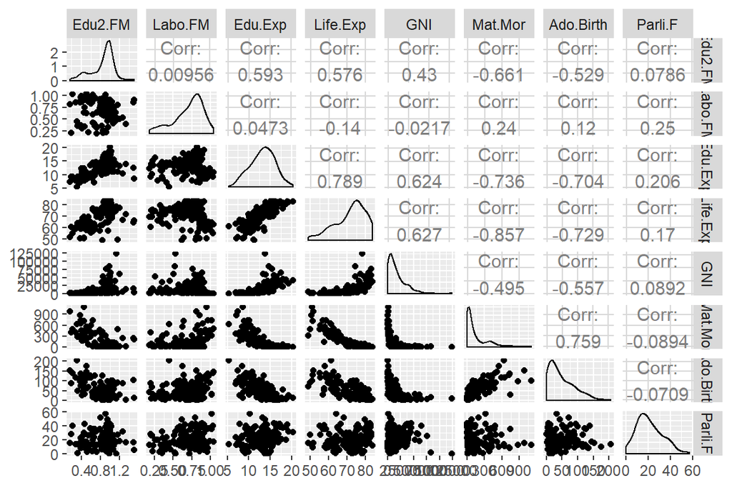

```r
library(GGally)
library(ggplot2)

human <- read.csv("http://s3.amazonaws.com/assets.datacamp.com/production/course_2218/datasets/human2.txt", header = T)
ggpairs(human)
```

```r
summary(human)
```

```
##     Edu2.FM          Labo.FM          Edu.Exp         Life.Exp
##  Min.   :0.1717   Min.   :0.1857   Min.   : 5.40   Min.   :49.00
##  1st Qu.:0.7264   1st Qu.:0.5984   1st Qu.:11.25   1st Qu.:66.30
##  Median :0.9375   Median :0.7535   Median :13.50   Median :74.20
##  Mean   :0.8529   Mean   :0.7074   Mean   :13.18   Mean   :71.65
##  3rd Qu.:0.9968   3rd Qu.:0.8535   3rd Qu.:15.20   3rd Qu.:77.25
##  Max.   :1.4967   Max.   :1.0380   Max.   :20.20   Max.   :83.50
##       GNI            Mat.Mor         Ado.Birth         Parli.F
##  Min.   :   581   Min.   :   1.0   Min.   :  0.60   Min.   : 0.00
##  1st Qu.:  4198   1st Qu.:  11.5   1st Qu.: 12.65   1st Qu.:12.40
##  Median : 12040   Median :  49.0   Median : 33.60   Median :19.30
##  Mean   : 17628   Mean   : 149.1   Mean   : 47.16   Mean   :20.91
##  3rd Qu.: 24512   3rd Qu.: 190.0   3rd Qu.: 71.95   3rd Qu.:27.95
##  Max.   :123124   Max.   :1100.0   Max.   :204.80   Max.   :57.50
```

There seems to be many variables that have clear relationships in this data. Especially striking seems to be the linear-looking relationship between life expenctancy and expected years in education. Many variables seem to have distincts outliers, especially at the upper end (eg. GNI). Parli.F seems to be difficult to show to have a clear relationship to any other variable. The variabilities of the variablse differ quite a lot, which needs to be taken into account in further analysis.

```r
PCA1 <- prcomp(human)
summary(PCA1)
```

```
## Importance of components:
##                              PC1      PC2   PC3   PC4   PC5   PC6    PC7    PC8
## Standard deviation     1.854e+04 185.5219 25.19 11.45 3.766 1.566 0.1912 0.1591
## Proportion of Variance 9.999e-01   0.0001  0.00  0.00 0.000 0.000 0.0000 0.0000
## Cumulative Proportion  9.999e-01   1.0000  1.00  1.00 1.000 1.000 1.0000 1.0000
```

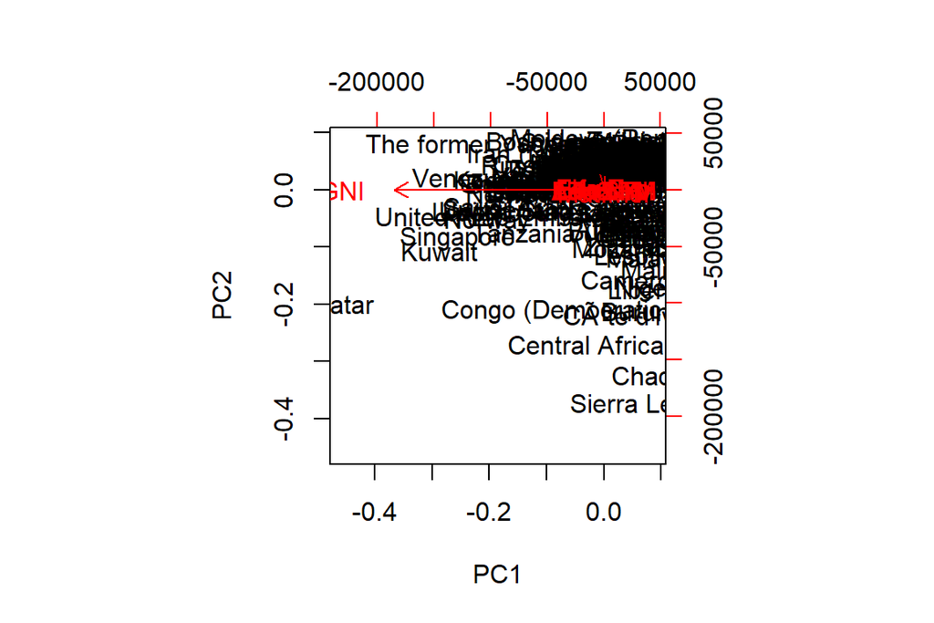

```r
biplot(PCA1, choices = 1:2)
```

Repeat with scaled data

```r
human_scaled <- scale(human)
PCA2 <-prcomp(human_scaled)
summary(PCA2)
```

```
## Importance of components:
##                           PC1    PC2     PC3     PC4     PC5     PC6     PC7
## Standard deviation     2.0708 1.1397 0.87505 0.77886 0.66196 0.53631 0.45900
## Proportion of Variance 0.5361 0.1624 0.09571 0.07583 0.05477 0.03595 0.02634
## Cumulative Proportion  0.5361 0.6984 0.79413 0.86996 0.92473 0.96069 0.98702
##                            PC8
## Standard deviation     0.32224
## Proportion of Variance 0.01298
## Cumulative Proportion  1.00000
```

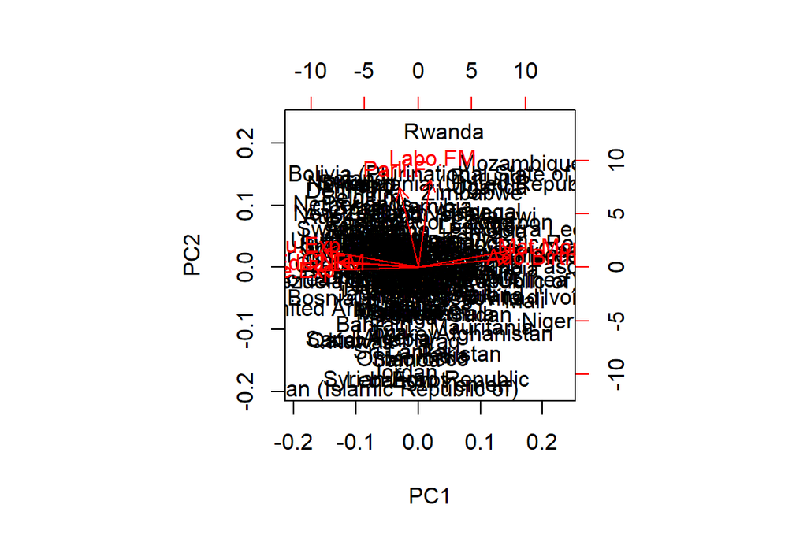

```r
biplot(PCA2, choices = 1:2)
```

The data is uninterpretable due to extreme variance in the 1st PCA. Standardization is absolutely necessary, since PCA cannot distinguish the relative strengths of variables if their variances do not match. In the 2nd PCA the first 2 principal components account for about 70% of the variance. In here we see that Mat.Mor and Ado.Birth are highly correlated with each other and with the first principal component. Likewise, expected years in education (Edu.exp), ratio of females and males in secondary education (Edu2.FM), GNI and life expectancy (Life.exp) are positively correlated among themselves and negatively correlated with PC1. The ratio of females and males in the labour force (Labo.FM) and the amount of females in parliamet (Parli.F) seems to be positively correlated with each other and PC2. The variation derived from these two variables is mostly missed in PC1.

It seems PC1 seems to separate countries on economic status, availability of healthcare etc. basic quality of life. This is evident on the high impact of variables such as life expectancy and education indices with PC1. PC2 on the other hand distinguishes countries more on the basis of social status and justice, especially by womens’ rights.